# Propensity Score Estimation with ML

Instead of tuning models the usual way, we tune directly on the covariate balance achieved when weighting on the inverse of the predicted class probabilities of a classifier.

For each model, we end up with one configuration that yielded the lowest remaining covariate imbalance.

# Packages & Data

```r
library(cobalt)
library(discrim)
library(furrr)
library(future)
library(progressr)
library(purrr)
library(tidymodels)

# for plots:
library(showtext)
library(sysfonts)

font_add(
  "Gyre",
  regular = "/usr/share/texmf/fonts/opentype/public/tex-gyre/texgyretermes-regular.otf"
)

showtext_auto()

theme_paper <- function(base_size = 14, base_family = "Gyre") {
  theme_minimal(base_size = base_size, base_family = base_family) +
    theme(
      panel.grid.major = element_line(color = "#E5E5E5", linewidth = 0.4),
      panel.grid.minor = element_blank(),

      axis.line = element_line(color = "black"),
      axis.ticks = element_line(color = "black"),

      axis.text = element_text(color = "black"),
      axis.title = element_text(color = "black"),

      plot.title = element_text(face = "bold", size = rel(1.2)),
      plot.subtitle = element_text(color = "black"),

      legend.position = "right",
      legend.title = element_text(face = "bold"),

      panel.background = element_blank(),
      plot.background = element_blank()
    )
}

theme_set(theme_paper())

set.seed(42)

fac_to_int <- function(x) {
  as.integer(as.character(x))
}
```

# Prep

Not using settlement features for now (measured at current location = post-treatment; need to match wartime locations which might get messy). We are using respondent characteristics:

- Age
- Sex
- Ethnicity
- Experienced other victimization

```r
survey <-
  readr::read_csv(here::here("data/survey.csv")) |>
  drop_na(crsv_self_family, resp_ethn) |>
  fastDummies::dummy_cols(c("resp_ethn", "resp_educ")) |>
  select(
    uuid, starts_with(c("resp_ethn", "resp_educ_")), resp_age,
    crsv_self_family, victim_other, resp_ethn,
    resp_male
  ) |>
  # outcome has to be factor for classification task with tidymodels,
  # first level is interpreted as event level ("treated" or here "moderated")
  mutate(crsv_self_family = factor(crsv_self_family, levels = c(1, 0)))
```

# Inspect

Feature correlations:

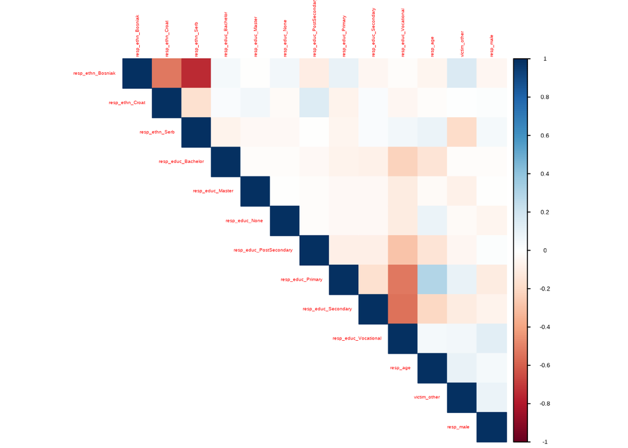

```r
survey |>
  select(-c(uuid, crsv_self_family, resp_ethn)) |>
  cor() |>
  corrplot::corrplot(method = "color", type = "upper", tl.cex = 0.6)
```

Correlations with treatment:

```r
survey |>
  select(crsv_self_family, where(is.numeric)) |>
  summarise(
    across(
      -crsv_self_family,
      \(x) cor(x, fac_to_int(crsv_self_family), use = "complete.obs")
    )
  ) |>
  pivot_longer(everything(), names_to = "variable", values_to = "r") |>
  arrange(desc(abs(r)))
```

```
# A tibble: 13 × 2
   variable                       r
   <chr>                      <dbl>
 1 victim_other             0.237
 2 resp_age                -0.115
 3 resp_educ_Vocational     0.0700
 4 resp_educ_Secondary     -0.0623
 5 resp_ethn_Serb          -0.0518
 6 resp_ethn_Bosniak        0.0405
 7 resp_male                0.0348
 8 resp_educ_PostSecondary -0.0337
 9 resp_educ_Master        -0.0298
10 resp_educ_None           0.0106
11 resp_educ_Primary       -0.00686
12 resp_educ_Bachelor      -0.00613
13 resp_ethn_Croat          0.00610
```

# Models & Workflow

- Random forest with tuned hyperparameters
- Penalized logistic regression with benchmark; tune both mixture (type) and penalty (amount) of regularization.

Data is imbalanced, but we won’t use oversampling or SMOTE to not alter the distributions (fit model on observed data generating process). Preprocessing recipe:

```r
prop_rec <-
  recipe(crsv_self_family ~ ., data = survey) |>
  update_role(uuid, new_role = "ID") |>
  step_normalize(all_numeric_predictors()) |>
  # drop resp_ethn (categorical) for modelling, but keep inside
  # data for later. Also, drop one of the dummies each bc of
  # collinearity (serve as baseline):
  step_rm(resp_ethn, resp_ethn_Croat, resp_educ_None)

# logistic regression also gets first-order interactions between all
# respondent attributes as features:
prop_rec_log <-
  prop_rec |>
  step_interact(terms = ~ starts_with("resp"):starts_with("resp"))
```

Models specifications. Since the logistic regression will include all first-order interaction terms, many of which may be irrelevant, we allow regularization (tuning type and strength):

```r
log_spec <-
  logistic_reg(
    penalty = tune(),
    mixture = tune() # 0 = ridge, 1 = lasso, 0 < mixture < 1 = elastic net
  ) |>
  set_engine("glmnet") |>
  set_mode("classification")

xgb_spec <-
  boost_tree(
    trees = tune(),
    tree_depth = tune(),
    learn_rate = tune(),
    min_n = tune(),
    loss_reduction = tune(),
    sample_size = tune(),
    mtry = tune()
  ) |>
  set_engine(
    "xgboost",
    objective = "binary:logistic",
    counts = FALSE
  ) |>
  set_mode("classification")

rf_spec <-
  rand_forest(
    trees = tune(),
    mtry = tune(),
    min_n = tune()
  ) |>
  set_engine(
    "ranger",
    probability = TRUE,
    importance = "impurity"
  ) |>
  set_mode("classification")
```

Hyperparameter grids for tuning. The ranges are not apriori, but are derived from prior testing.

```r
log_grid <-
  grid_space_filling(
    penalty(range = c(-3, -1)),  # log10 scale
    mixture(range = c(0, 1)),
    size = 50
  )

xgb_grid <-
  grid_space_filling(
    trees(range = c(500, 1500)),
    tree_depth(range = c(1, 5)),
    learn_rate(range = c(1e-3, .1), trans = NULL),
    min_n(range = c(3, 30)),
    loss_reduction(range = c(1e-3, .99), trans = NULL),
    sample_size = sample_prop(range = c(.7, .9)),
    mtry = mtry_prop(range = c(.6, 1)),
    size = 200,
    type = "latin_hypercube"
  )

rf_grid <-
  grid_space_filling(
    trees(range = c(500, 2000)),
    mtry = mtry_prop(range = c(0.3, 1)),
    min_n(range = c(5, 150)),
    size = 150,
    type = "latin_hypercube"
  )
```

# Helper functions for tuning

Functions to compute balance statistics from fitted tidymodels workflow:

```r
augment_ipw <- function(wflow, data, clip = 0) {
  form <- formula(extract_recipe(wflow))
  lhs <- rlang::f_lhs(form)

  df_fit <-
    wflow |>
    augment(data) |>
    rename(prop = .pred_1) |>
    mutate(!!lhs := fac_to_int(!!lhs))

  true_prop <- mean(pull(df_fit, lhs), na.rm = TRUE)

  df_fit |>
    mutate(
      prop = pmin(pmax(prop, clip), 1 - clip),
      ipw = if_else(
        !!lhs == 1,
        true_prop / prop,
        (1 - true_prop) / (1 - prop)
      )
    )
}

balance_stats <- function(formula, data, weights) {
  balance <- bal.tab(
    formula,
    weights = weights,
    data = data,
    estimand = "ATE"
  )

  tibble(
    mean_asmd = mean(abs(balance$Balance$Diff.Adj)),
    max_asmd = max(abs(balance$Balance$Diff.Adj)),
    ess_treat = balance$Observations["Adjusted", ]$Treated,
    ess_cont = balance$Observations["Adjusted", ]$Control
  )
}
```

# Tuning

For every model, fit every config from the grid to the data, calculate stabilized inverse probability weights & compute remaining imbalance. We are trying to find the model/config that generates the best balance.

Model configs:

```r
models <- tribble(
  ~id,             ~spec,     ~recipe,      ~grid,
  "Random Forest", rf_spec,   prop_rec,     rf_grid,
  "XGBoost",       xgb_spec,  prop_rec,     xgb_grid,
  "Elastic Net",   log_spec,  prop_rec_log, log_grid,
)

models
```

```
# A tibble: 3 × 4
  id            spec      recipe   grid
  <chr>         <list>    <list>   <list>
1 Random Forest <spec[?]> <recipe> <tibble [150 × 3]>
2 XGBoost       <spec[?]> <recipe> <tibble [200 × 7]>
3 Elastic Net   <spec[?]> <recipe> <tibble [50 × 2]>
```

Tuning procedure. Parallelizing over all but one available cores to speed this up.

```r
# Using constant formula since `prop_rec_log` includes interaction terms
# that tidymodels builds into the df (means the formula extracted from
# that recipe will have columns that do not exist in the original data):
FORMULA <- formula(prep(prop_rec, survey))

plan(multisession, workers = parallel::detectCores() - 1)

tuning_res <- pmap(models, function(id, spec, recipe, grid) {

  n <- nrow(grid)

  message(sprintf("\nFitting %d models for %s...", n, id))

  with_progress({

    p <- progressor(steps = n)

    # iterate over grid:

    future_map(seq(n), function(i) {

      p()

      # fit each model config. to the data...

      hyperparams <- grid[i, ]

      wf <-
        workflow() |>
        add_recipe(recipe) |>
        add_model(update(spec, hyperparams)) |>
        fit(survey)

      df_fit <- wf |> augment_ipw(survey)

      # ...and compute balance:
      bal <- balance_stats(FORMULA, df_fit, df_fit$ipw)
      bind_cols(tibble(id = id, config = list(hyperparams)), bal)

    }, .options = furrr_options(seed = 42)) |> bind_rows()

  })

}) |> bind_rows()
```

## Tuning results

Also fitting a plain logistic regression on the prepped data with all interaction terms, as benchmark (in practice, researchers often resort to using logistic regression to estimate propensity scores, so this is a reasonable benchmark):

```r
plain_log <-
  logistic_reg() |>
  set_engine("glm") |>
  set_mode("classification")

plain_log_wf <-
  workflow() |>
  add_recipe(prop_rec_log) |> # `prop_rec_log` adds first-order interactions
  add_model(plain_log)

plain_log_fit <-
  plain_log_wf |>
  fit(survey) |>
  augment_ipw(survey) |>
  (\(df) balance_stats(FORMULA, df, df$ipw))() |>
  bind_cols(id = "Logistic Regression")
```

Best balance achieved by each model, by lowest mean ASMD:

```r
tuning_res |>
  group_by(id) |>
  arrange(mean_asmd, .by_group = TRUE) |>
  slice(1) |>
  ungroup() |>
  bind_rows(plain_log_fit) |>
  arrange(mean_asmd)
```

```
# A tibble: 4 × 6
  id                  config           mean_asmd max_asmd ess_treat ess_cont
  <chr>               <list>               <dbl>    <dbl>     <dbl>    <dbl>
1 XGBoost             <tibble [1 × 7]>    0.0224   0.0473      51.0     805.
2 Elastic Net         <tibble [1 × 2]>    0.0251   0.0669      65.8     827.
3 Random Forest       <tibble [1 × 3]>    0.0414   0.160       85.7     828.
4 Logistic Regression <NULL>              0.0448   0.102       42.4     814.
```

Distribution of mean ASMDs by model:

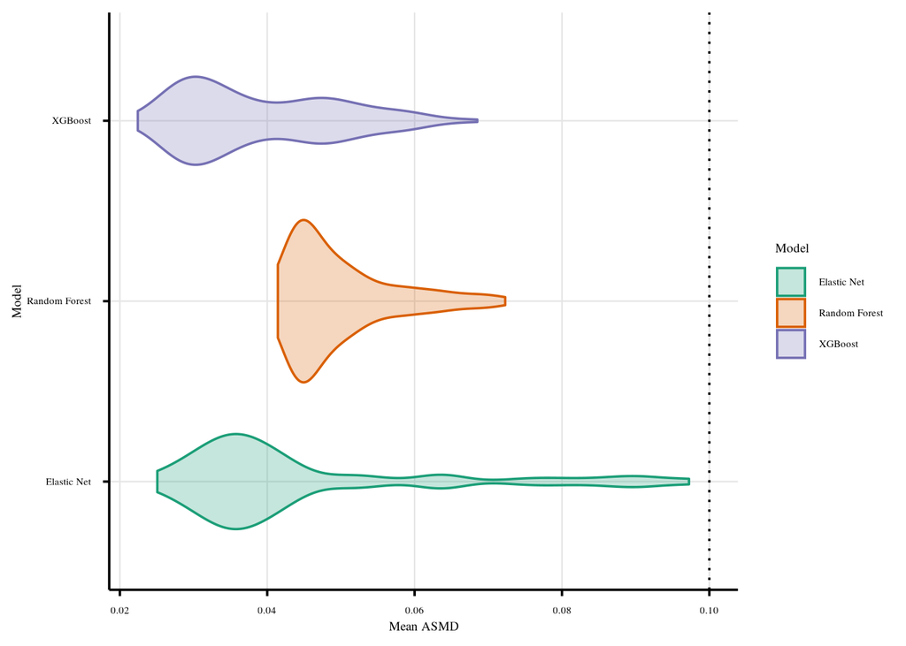

```r
tuning_res |>
  ggplot(aes(x = mean_asmd, y = id, color = id, fill = id)) +
  geom_vline(xintercept = .1, lty = "dotted") +
  geom_violin(alpha = .25) +
  labs(fill = "Model", color = "Model", y = "Model", x = "Mean ASMD") +
  scale_color_brewer(palette = "Dark2") +
  scale_fill_brewer(palette = "Dark2")
```

```r
#ggsave(here::here("figs/mean_asmd_by_model.pdf"), width = 7, height = 5)
```

Max ASMDs:

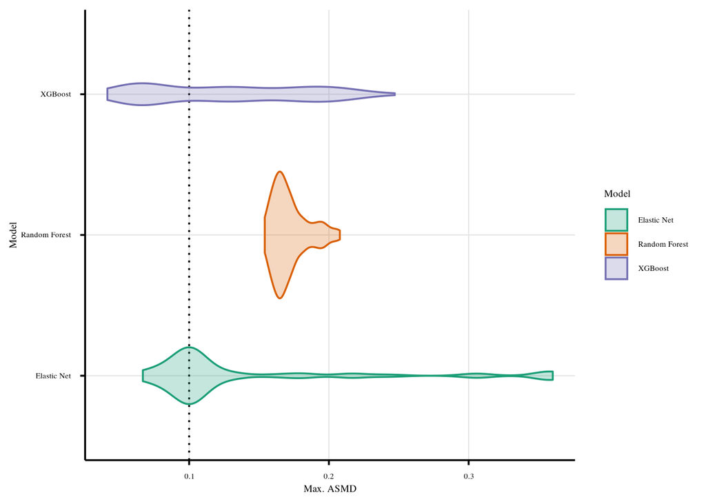

```r
tuning_res |>
  ggplot(aes(x = max_asmd, y = id, color = id, fill = id)) +
  geom_vline(xintercept = .1, lty = "dotted") +
  geom_violin(alpha = .25) +
  labs(fill = "Model", color = "Model", y = "Model", x = "Max. ASMD") +
  scale_color_brewer(palette = "Dark2") +
  scale_fill_brewer(palette = "Dark2")
```

```r
#ggsave(here::here("figs/max_asmd_by_model.pdf"), width = 7, height = 5)
```

ESS vs. mean ASMD:

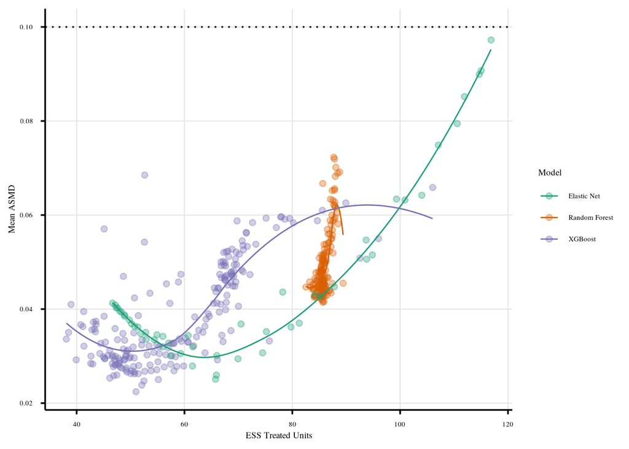

```r
tuning_res |>
  ggplot(aes(x = ess_treat, y = mean_asmd, color = id)) +
  geom_hline(yintercept = .1, lty = "dotted") +
  geom_point(alpha = .34) +
  geom_smooth(se = FALSE, linewidth = .5) +
  labs(x = "ESS Treated Units", y = "Mean ASMD", color = "Model") +
  scale_color_brewer(palette = "Dark2")
```

```r
#ggsave(here::here("figs/ess_vs_mean_asmd.pdf"), width = 7, height = 5)
```

ESS vs. max ASMD

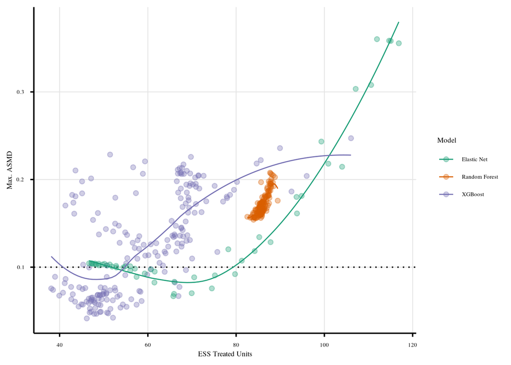

```r
tuning_res |>
  ggplot(aes(x = ess_treat, y = max_asmd, color = id)) +
  geom_hline(yintercept = .1, lty = "dotted") +
  geom_point(alpha = .34) +
  geom_smooth(se = FALSE, linewidth = .5) +
  labs(x = "ESS Treated Units", y = "Max. ASMD", color = "Model") +
  scale_color_brewer(palette = "Dark2")
```

```r
#ggsave(here::here("figs/ess_vs_max_asmd.pdf"), width = 7, height = 5)
```

Mean vs. Max ASMD (checking for “sacrifice one”-behavior):

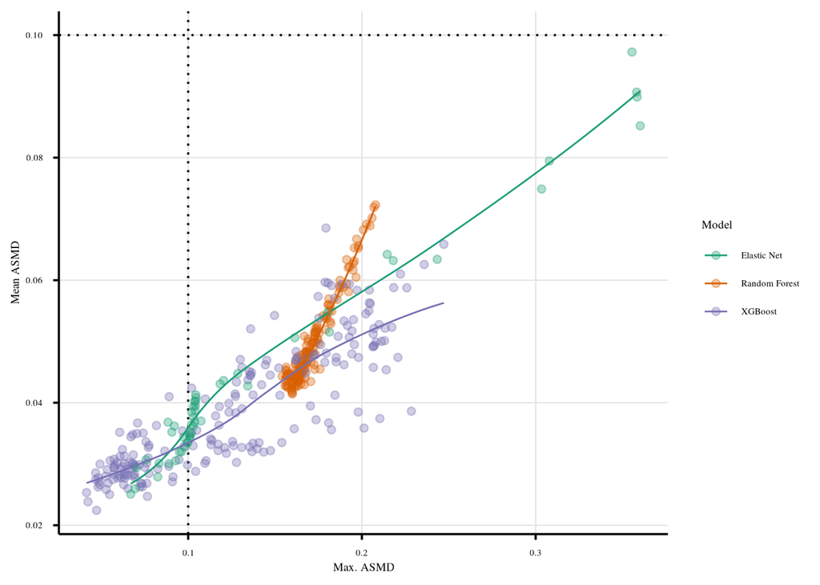

```r
tuning_res |>
  ggplot(aes(x = max_asmd, y = mean_asmd, color = id)) +
  geom_vline(xintercept = .1, lty = "dotted") +
  geom_hline(yintercept = .1, lty = "dotted") +
  geom_point(alpha = .34) +
  geom_smooth(se = FALSE, linewidth = .5) +
  labs(x = "Max. ASMD", y = "Mean ASMD", color = "Model") +
  scale_color_brewer(palette = "Dark2")
```

```r
#ggsave(here::here("figs/mean_vs_max_asmd.pdf"), width = 7, height = 5)
```

# Hyperparams

Exporting hyperparameter plots: for each model, how does each hyperparameter impact mean ASMD?

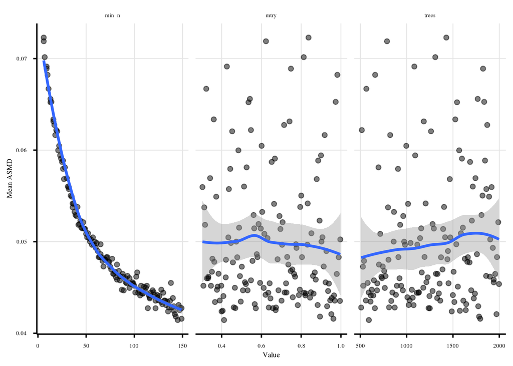

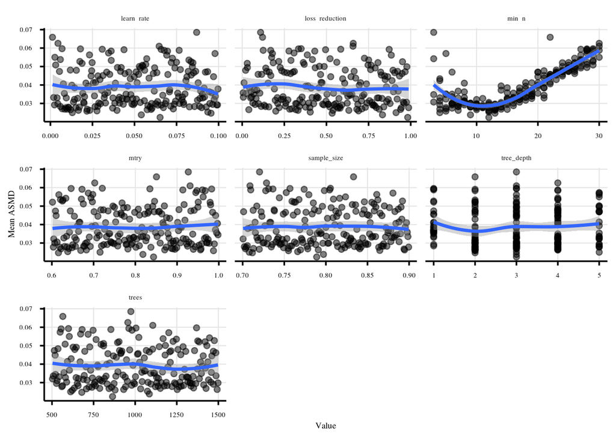

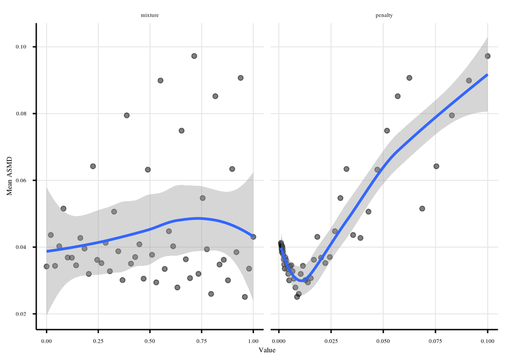

```r
models |>
  pull(id) |>
  map(function(model) {

    name <- tolower(gsub(" ", "_", model))

    suppressWarnings({

      p <-
        tuning_res |>
        filter(id == model) |>
        unnest(config) |>
        select(id:mean_asmd) |>
        pivot_longer(
          cols = -c(id, mean_asmd),
          names_to = "param",
          values_to = "value"
        ) |>
        ggplot(aes(x = value, y = mean_asmd)) +
        geom_point(alpha = .5) +
        geom_smooth() +
        facet_wrap(~param, scales = "free_x") +
        labs(x = "Value", y = "Mean ASMD")

    })

    #ggsave(
    #  here::here(glue::glue("figs/hyperparams_{name}.pdf")),
    #  plot = p,
    #  width = 7,
    #  height = 5
    #)

    p
})
```

```r
# ^ could use `walk()` to save but I wanted to show the plots in the HTML
```

# Export

Getting the best config for each model:

```r
models_full <-
  tuning_res |>
  group_by(id) |>
  arrange(mean_asmd, .by_group = TRUE) |>
  slice(1) |>
  ungroup() |>
  select(id, config) |>
  right_join(models)

models_full |> pull(config) |> set_names(models_full$id)
```

```
$`Elastic Net`
# A tibble: 1 × 2
  penalty mixture
    <dbl>   <dbl>
1 0.00869   0.959

$`Random Forest`
# A tibble: 1 × 3
  trees  mtry min_n
  <int> <dbl> <int>
1   592 0.412   145

$XGBoost
# A tibble: 1 × 7
  trees tree_depth learn_rate min_n loss_reduction sample_size  mtry
  <int>      <int>      <dbl> <int>          <dbl>       <dbl> <dbl>
1   864          3     0.0652    12          0.982       0.789 0.844
```

Fitting the best models to the data & getting estimates, so that for each unit we have an estimated propensity score & IPW from each best model:

```r
estimates <-
  models_full |>
  mutate(

    wflow = map2(recipe, spec, function(rec, mod) {
      workflow() |>
        add_recipe(rec) |>
        add_model(mod)
    }),

    final = map2(wflow, config, \(wf, cfg) finalize_workflow(wf, cfg)),

    fit = map(final, function(wf) {
      wf |>
        fit(survey) |>
        augment_ipw(survey)
    })

  ) |>
  select(id, fit) |>
  unnest(fit) |>
  select(id, uuid, ipw, prop, everything())

estimates
```

```
# A tibble: 2,856 × 21
   id         uuid    ipw   prop .pred_class .pred_0 resp_ethn resp_ethn_Bosniak
   <chr>      <chr> <dbl>  <dbl> <fct>         <dbl> <chr>                 <int>
 1 Elastic N… uuid… 0.917 0.0438 0             0.956 Bosniak                   1
 2 Elastic N… uuid… 1.09  0.196  0             0.804 Bosniak                   1
 3 Elastic N… uuid… 0.949 0.0762 0             0.924 Bosniak                   1
 4 Elastic N… uuid… 0.946 0.0731 0             0.927 Bosniak                   1
 5 Elastic N… uuid… 0.894 0.0194 0             0.981 Bosniak                   1
 6 Elastic N… uuid… 0.921 0.0476 0             0.952 Bosniak                   1
 7 Elastic N… uuid… 0.925 0.0520 0             0.948 Bosniak                   1
 8 Elastic N… uuid… 0.943 0.0704 0             0.930 Bosniak                   1
 9 Elastic N… uuid… 0.943 0.0704 0             0.930 Bosniak                   1
10 Elastic N… uuid… 0.932 0.0594 0             0.941 Bosniak                   1
# ℹ 2,846 more rows
# ℹ 13 more variables: resp_ethn_Croat <int>, resp_ethn_Serb <int>,
#   resp_educ_Bachelor <int>, resp_educ_Master <int>, resp_educ_None <int>,
#   resp_educ_PostSecondary <int>, resp_educ_Primary <int>,
#   resp_educ_Secondary <int>, resp_educ_Vocational <int>, resp_age <dbl>,
#   crsv_self_family <int>, victim_other <dbl>, resp_male <dbl>
```

Exporting:

```r
estimates |>
  select(id, uuid, ipw, prop) |>
  readr::write_csv(here::here("data/propensity_scores.csv"))
```

# Additional diagnostics

Overlap:

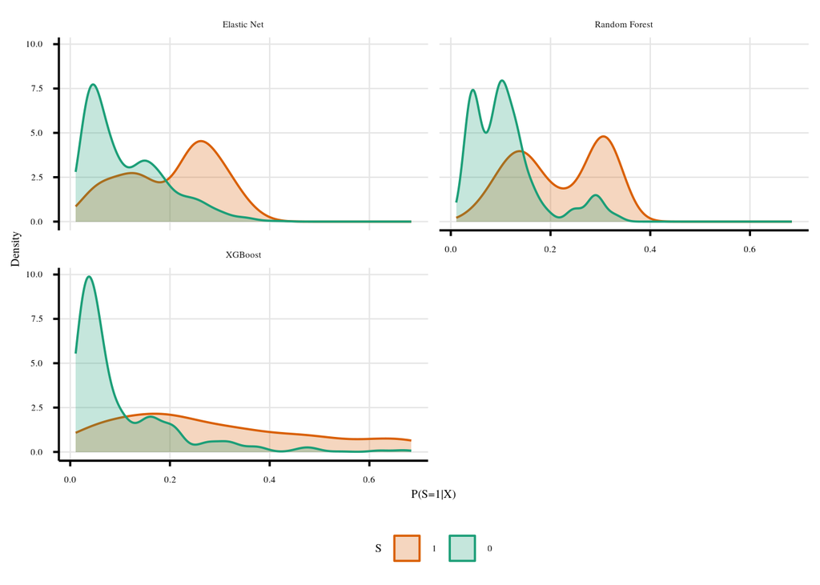

```r
estimates |>
  mutate(crsv_self_family = factor(crsv_self_family, levels = c(1, 0))) |>
  ggplot(aes(x = prop, color = crsv_self_family, fill = crsv_self_family)) +
  geom_density(alpha = .25) +
  facet_wrap(~id, ncol = 2) +
  theme(legend.position = "bottom") +
  labs(
    x = "P(S=1|X)",
    y = "Density",
    fill = "S",
    color = "S"
  ) +
  scale_color_brewer(palette = "Dark2", direction = -1) +
  scale_fill_brewer(palette = "Dark2", direction = -1)
```

```r
#ggsave(here::here("figs/overlap_by_model.pdf"), width = 7, height = 5)
```

Balance:

```r
balances <-
  estimates |>
  group_by(id) |>
  nest() |>
  ungroup() |>
  mutate(
    balance = map(data, function(df) {

      tab <- bal.tab(
        FORMULA,
        weights = df$ipw,
        data = df,
        estimand = "ATE",
        un = TRUE
      )$Balance

      tab |>
        tibble::rownames_to_column("covariate") |>
        rename_with(\(n) tolower(gsub("\\.", "_", n)))

    })
  ) |>
  select(id, balance) |>
  unnest(balance)
```

Visually:

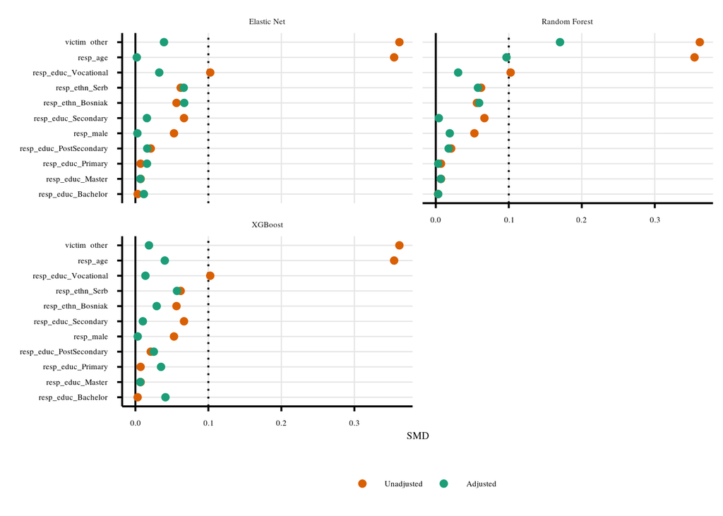

```r
balances |>
  select(-type) |>
  pivot_longer(starts_with("diff"), names_to = "adj", values_to = "diff") |>
  mutate(
    adj = adj |> replace_values(
      "diff_un" ~ "Unadjusted",
      "diff_adj" ~ "Adjusted"
    ),
    adj = factor(adj, levels = c("Unadjusted", "Adjusted")),
    diff = abs(diff)
  ) |>
  ggplot(
    aes(
      x = diff,
      y = forcats::fct_reorder(covariate, diff),
      color = adj
    )
  ) +
  geom_vline(xintercept = 0) +
  geom_vline(xintercept = .1, lty = "dotted") +
  geom_point() +
  facet_wrap(~id, ncol = 2) +
  labs(x = "SMD", y = "", color = "") +
  theme(legend.position = "bottom") +
  scale_color_brewer(palette = "Dark2", direction = -1) +
  scale_fill_brewer(palette = "Dark2", direction = -1)
```

```r
#ggsave(here::here("figs/final_balance_love_plot.pdf"), width = 7, height = 5)
```

Effective Sample Size:

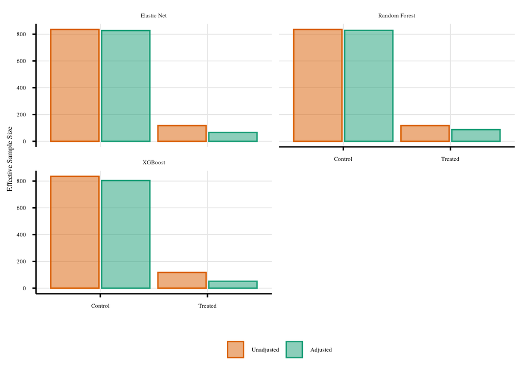

```r
estimates |>
  group_by(id) |>
  nest() |>
  ungroup() |>
  mutate(
    balance = map(data, function(df) {

      obs <- bal.tab(
        FORMULA,
        weights = df$ipw,
        data = df,
        estimand = "ATE",
        un = TRUE
      )$Observations

      obs |> tibble::rownames_to_column("adj")

    })
  ) |>
  select(id, balance) |>
  unnest(balance) |>
  mutate(adj = factor(adj, levels = c("Unadjusted", "Adjusted"))) |>
  pivot_longer(c(Control, Treated), names_to = "treat", values_to = "val") |>
  ggplot(aes(x = treat, y = val, color = adj, fill = adj)) +
  geom_col(position = position_dodge(width = .95), alpha = .5) +
  facet_wrap(~id, ncol = 2) +
  theme(legend.position = "bottom") +
  labs(x = "", y = "Effective Sample Size", color = "", fill = "") +
  scale_color_brewer(palette = "Dark2", direction = -1) +
  scale_fill_brewer(palette = "Dark2", direction = -1)
```

```r
#ggsave(here::here("figs/final_balance_ess.pdf"), width = 7, height = 5)
```